# DBSCAN Example

Source : http://www.sthda.com/english/wiki/dbscan-density-based-clustering-for-discovering-clusters-in-large-datasets-with-noise-unsupervised-machine-learning

1 Concepts of density-based clustering

Partitioning methods (K-means, PAM clustering) and hierarchical clustering are suitable for finding spherical-shaped clusters or convex clusters. In other words, they work well for compact and well separated clusters. Moreover, they are also severely affected by the presence of noise and outliers in the data.

Unfortunately, real life data can contain: i) clusters of arbitrary shape such as those shown in the figure below (oval, linear and “S” shape clusters); ii) many outliers and noise.

The figure below shows a dataset containing nonconvex clusters and outliers/noises. The simulated dataset multishapes [in factoextra package] is used.

http://www.sthda.com/sthda/RDoc/figure/clustering/dbscan-density-based-clustering-data-dbscan-1.png

```
argument frame is deprecated; please use ellipse instead.
```

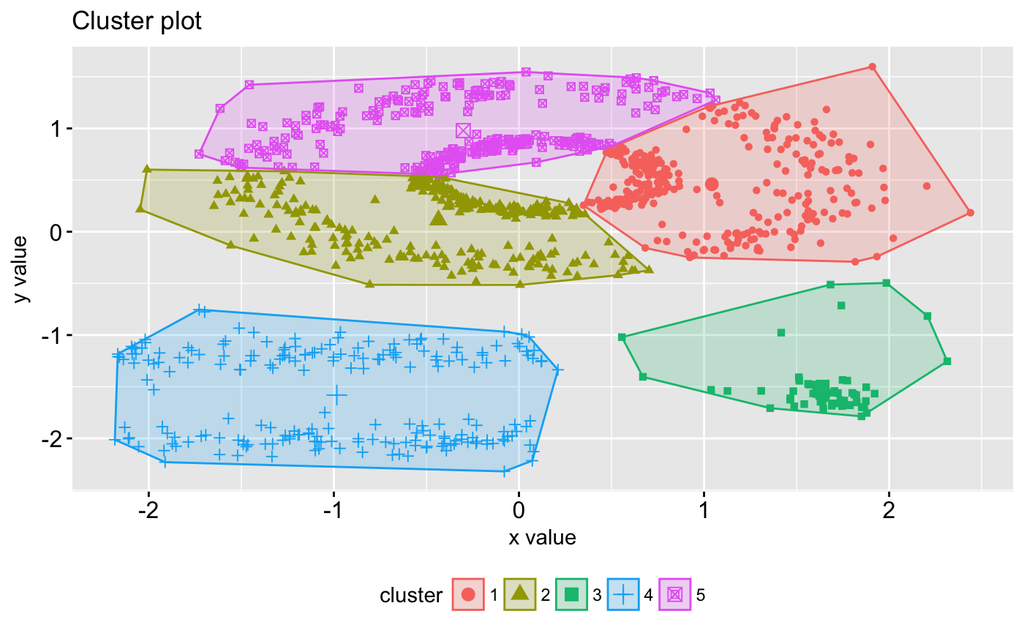

```r
# if(!require(devtools)) install.packages("devtools")
# devtools::install_github("kassambara/factoextra")
# install.packages("factoextra")
library(factoextra)
data(multishapes)
df <- multishapes[, 1:2]
set.seed(123)
km.res <- kmeans(df, 5, nstart = 25)
fviz_cluster(km.res, df, frame = FALSE, geom = "point")
```

We know there are 5 five clusters in the data, but it can be seen that k-means method inaccurately identify the 5 clusters. This chapter describes DBSCAN, a density-based clustering algorithm, introduced in Ester et al. 1996, which can be used to identify clusters of any shape in data set containing noise and outliers. DBSCAN stands for Density-Based Spatial Clustering and Application with Noise.

The advantages of DBSCAN are:

1. Unlike K-means, DBSCAN does not require the user to specify the number of clusters to be generated.
2. DBSCAN can find any shape of clusters. The cluster doesn`t have to be circular.
3. DBSCAN can identify outliers

http://www.sthda.com/sthda/RDoc/images/dbscan-idea.png

DBSCAN is based on this intuitive notion of “clusters” and “noise”. The key idea is that for each point of a cluster, the neighborhood of a given radius has to contain at least a minimum number of points.

Three R packages are used in this article:

1. fpc and dbscan for computing density-based clustering
2. factoextra for visualizing clusters

The R packages fpc and dbscan can be installed as follow:

```r
# install.packages("fpc")
# install.packages("dbscan")
# In the following examples, we`ll use fpc package. A simplified format of the function is:
db1 <- dbscan::dbscan(df, eps=0.15, MinPts = 5, scale = FALSE,  method = c("hybrid", "raw", "dist"))
```

```
converting argument MinPts (fpc) to minPts (dbscan)!
```

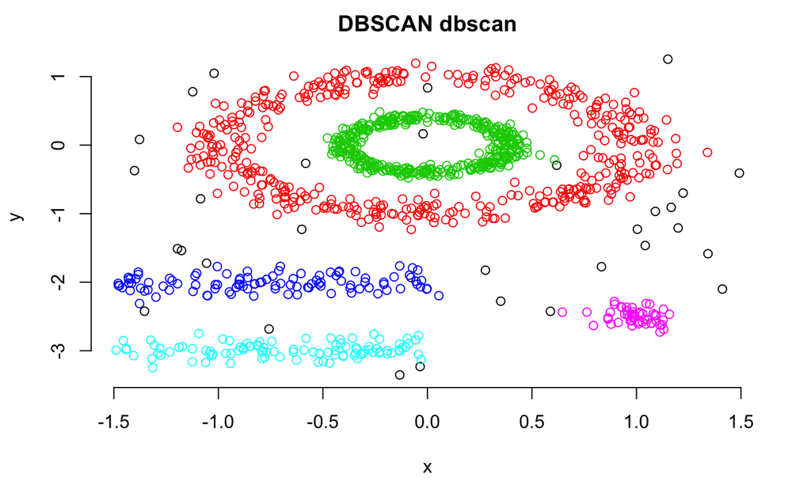

```r
set.seed(123)
db2 <- fpc::dbscan(df, eps=0.15, MinPts = 5)
# Plot DBSCAN results
plot(db1, df, main = "DBSCAN dbscan", frame = FALSE)
```

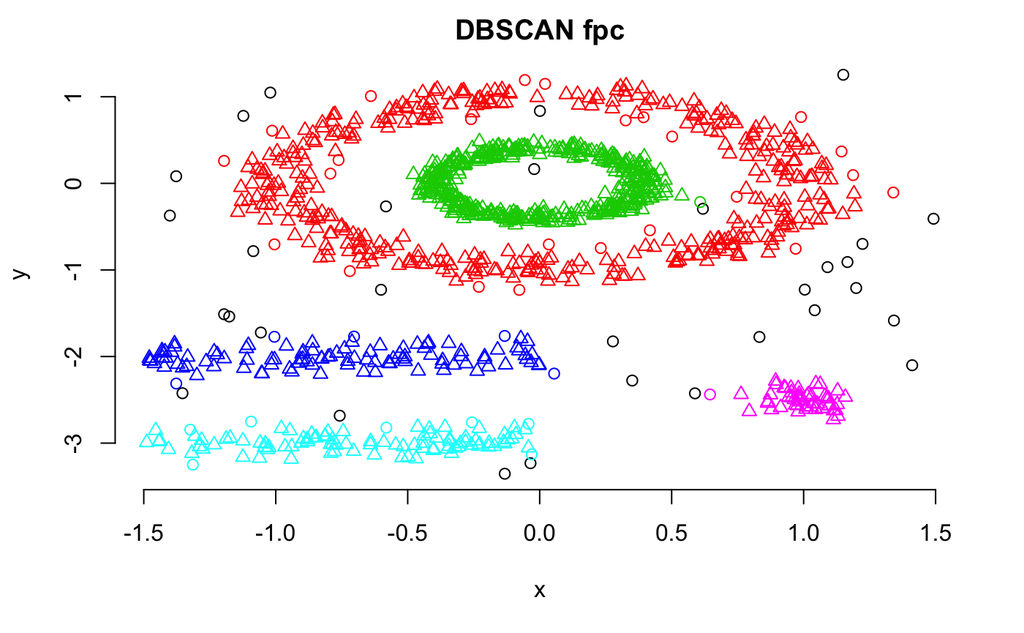

```r
plot(db2, df, main = "DBSCAN fpc", frame = FALSE)
```

Note that, the function plot.dbscan() uses different point symbols for core points (i.e, seed points) and border points. Black points correspond to outliers. You can play with eps and MinPts for changing cluster configurations.

It can be seen that DBSCAN performs better for these data sets and can identify the correct set of clusters compared to k-means algorithms. It`s also possible to draw the plot above using the function fviz_cluster() [ in factoextra package]:

```
argument frame is deprecated; please use ellipse instead.
```

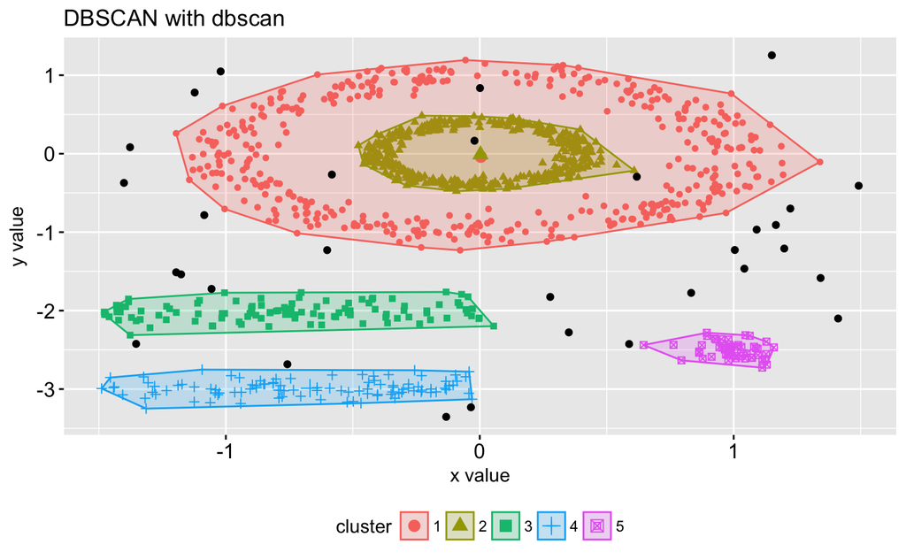

```r
fviz_cluster(db1, df, stand = FALSE, frame = FALSE, geom = "point", main = "DBSCAN with dbscan")
```

```
argument frame is deprecated; please use ellipse instead.
```

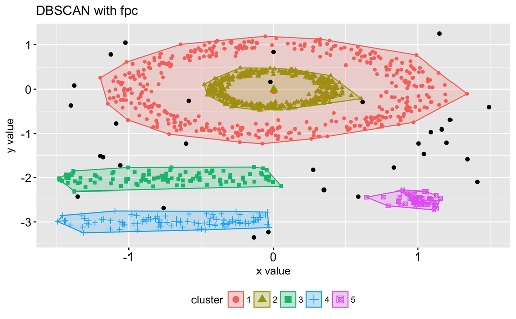

```r
fviz_cluster(db2, df, stand = FALSE, frame = FALSE, geom = "point", main = "DBSCAN with fpc")
```

The result of fpc::dbscan() function can be displayed as follow:

```r
# Print DBSCAN
print(db1)
```

```
DBSCAN clustering for 1100 objects.
Parameters: eps = 0.15, minPts = 5
The clustering contains 5 cluster(s) and 31 noise points.

  0   1   2   3   4   5
 31 410 405 104  99  51

Available fields: cluster, eps, minPts
```

```r
print(db2)
```

```
dbscan Pts=1100 MinPts=5 eps=0.15
        0   1   2   3  4  5
border 31  24   1   5  7  1
seed    0 386 404  99 92 50
total  31 410 405 104 99 51
```

In the table above, column names are cluster number. Cluster 0 corresponds to outliers (black points in the DBSCAN plot).

5 Method for determining the optimal eps value

The method proposed here consists of computing the he k-nearest neighbor distances in a matrix of points. The idea is to calculate, the average of the distances of every point to its k nearest neighbors. The value of k will be specified by the user and corresponds to MinPts. Next, these k-distances are plotted in an ascending order. The aim is to determine the “knee”, which corresponds to the optimal eps parameter. A knee corresponds to a threshold where a sharp change occurs along the k-distance curve. The function kNNdistplot() [in dbscan package] can be used to draw the k-distance plot:

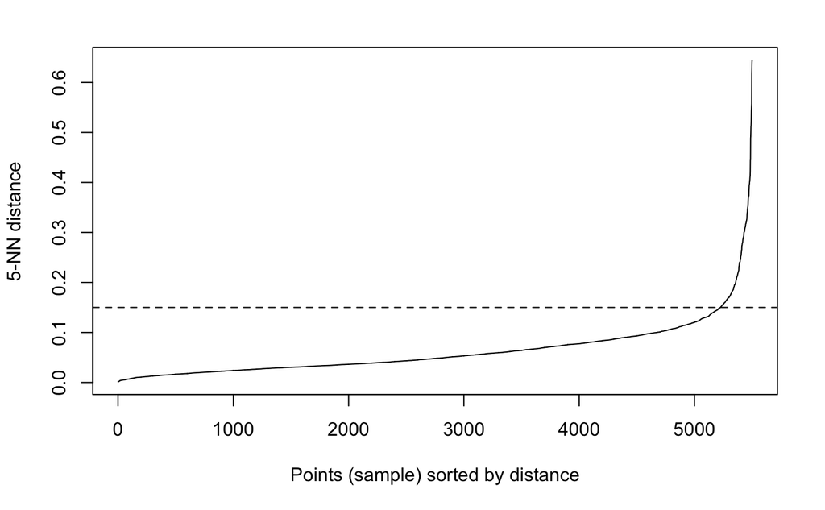

```r
dbscan::kNNdistplot(df, k =  5)
abline(h = 0.15, lty = 2)
```

It can be seen that the optimal eps value is around a distance of 0.15. 6 Cluster predictions with DBSCAN algorithm

## The function predict.dbscan(object, data, newdata) [in fpc package] can be used to predict the clusters for the points in newdata. For more details, read the documentation (?predict.dbscan).

7 Application of DBSCAN on a real data

The iris dataset is used:

```r
# Load the data
data("iris")
iris <- as.matrix(iris[, 1:4])
```

The optimal value of “eps” parameter can be determined as follow:

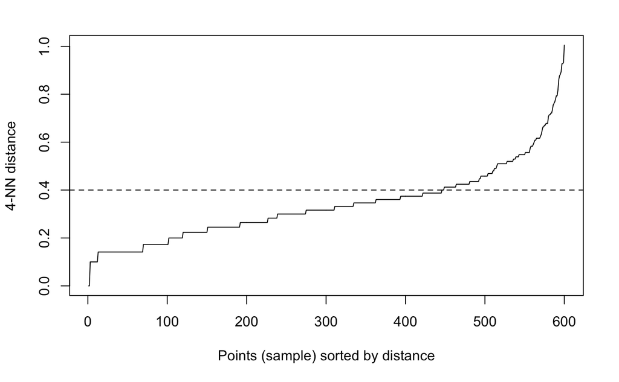

```r
dbscan::kNNdistplot(iris, k =  4)
abline(h = 0.4, lty = 2)
```

Compute DBSCAN using fpc::dbscan() and dbscan::dbscan(). Make sure that the 2 packages are installed:

```r
set.seed(123)
# fpc package
res.fpc <- fpc::dbscan(iris, eps = 0.4, MinPts = 4)
# dbscan package
res.db <- dbscan::dbscan(iris, 0.4, 4)
```

Note that the function dbscan:dbscan() is a fast re-implementation of DBSCAN algorithm. The implementation is significantly faster and can work with larger data sets than the function fpc:dbscan().

Make sure that both version produce the same results:

```r
all(res.fpc$cluster == res.db$cluster)
```

```
[1] TRUE
```

Result :

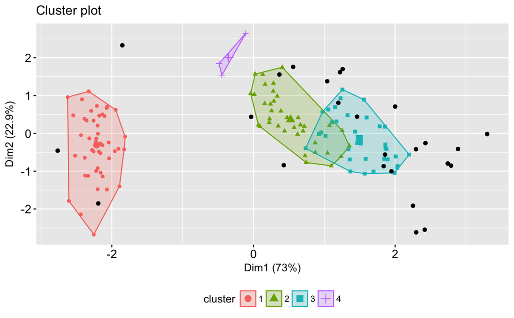

```r
fviz_cluster(res.fpc, iris, geom = "point")
```